# Assignment 3 - Text Mining

Author

Isabella Villanueva

### Loading in the dataset

```r
if (!file.exists("pubmed.csv")) #PubMed Dataset
  download.file(
    url = "https://raw.githubusercontent.com/USCbiostats/data-science-data/master/03_pubmed/pubmed.csv",
    destfile = "pubmed.csv",
    method   = "libcurl",
    timeout  = 60
    )
pubmed <- data.table::fread("pubmed.csv")
pubmed <- as.data.frame(pubmed)

pubmed_summary <- head(pubmed)
library(DT)
datatable((pubmed_summary), class = 'cell-border stripe')
```

|  | abstract | term |
| --- | --- | --- |
| 1 | Background and aims: Many patients with coronavirus disease 2019 (COVID-19) have underlying cardiovascular (CV) disease or develop acute cardiac injury during the course of the illness. Adequate under… | covid |
| 2 | Introduction: Contradictory data have been reported on the incidence of stroke in patients with COVID-19 and the risk of SARS-CoV-2 infection among patients with history of stroke. Methods: This study… | covid |
| 3 | This article aims at collecting all information needed for dentists regarding the COVID-19 pandemic throughout the world by reviewing articles published by now. In late 2019, a pneumonia outbreak of u… | covid |
| 4 | OBJECTIVE. The objective of our study was to determine the misdiagnosis rate of radiologists for coronavirus disease 2019 (COVID-19) and evaluate the performance of chest CT in the diagnosis and manag… | covid |
| 5 | Background: Much of the focus regarding the global pandemic of coronavirus disease of 2019 (COVID-19) has been on the cardiovascular, pulmonary, and hematologic complications. However, neurologic comp… | covid |
| 6 | The World Health Organization (WHO) has issued a warning that, although the 2019 novel coronavirus (COVID-19) from Wuhan City (China), is not pandemic, it should be contained to prevent the global spr… | covid |

### Loading the necessary packages

```r
suppressWarnings(suppressMessages(library(dplyr)))
suppressWarnings(suppressMessages(library(tidytext)))
suppressWarnings(suppressMessages(library(ggplot2)))
suppressWarnings(suppressMessages(library(forcats)))
suppressWarnings(suppressMessages(library(stringr)))
suppressWarnings(suppressMessages(library(textdata)))
```

## Text Mining

### 1. Tokenize the abstracts and count the number of each token. Do you see anything interesting?

When looking at the count for the top 10 tokens of the abstracts without removing the stop words (filler words like the, and, of), stop words are the most used words – where “covid” and “19” are the only words with substantial meaning in these top 10 tokens.

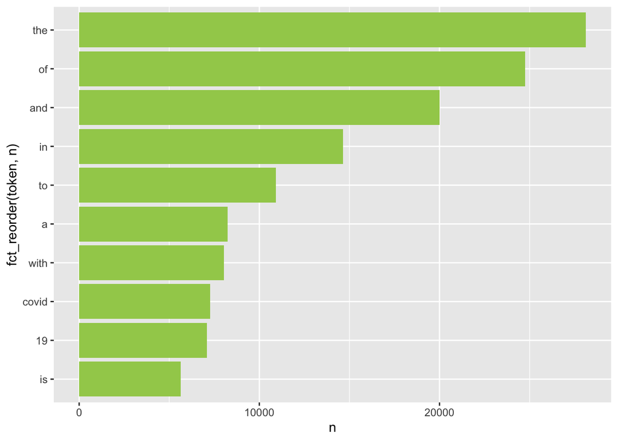

```r
pubmed %>%
  unnest_tokens(token, abstract) %>%
  count(token, sort = TRUE) %>% #Counting the number of each token in abstracts
  top_n(10,n) %>% #Showing the top 10 tokens
  ggplot(aes(n, fct_reorder(token, n))) +
  geom_col(fill = "darkolivegreen3")
```

#### Does removing stop words change what tokens appear as the most frequent? What are the 5 most common tokens for each search term after removing stopwords?

Removing the stop words does change what tokens appear as the most frequent, now with the words “covid”, “patients”, “cancer”, “prostate”, and “disease” all being the leading tokens.

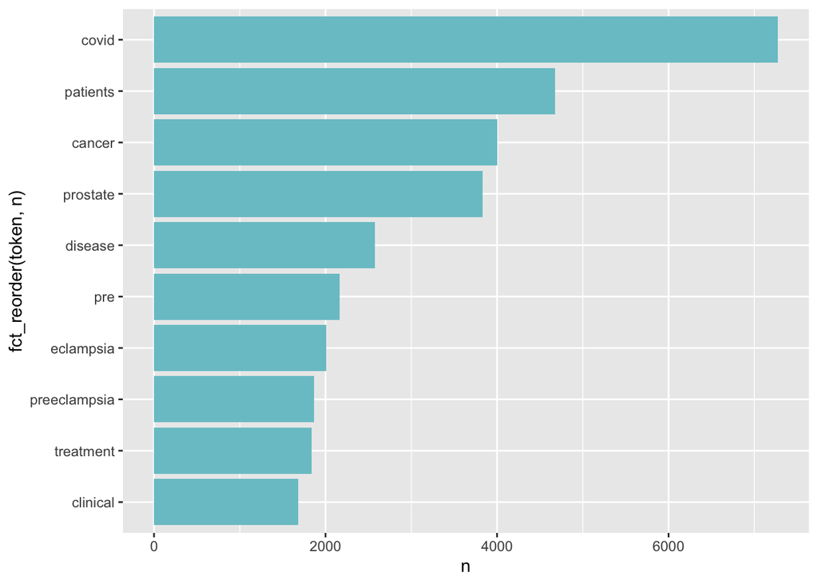

```r
pubmed |>
  unnest_tokens(token, abstract) |>
  anti_join(stop_words, by = c("token" = "word")) |> #Removal of stop_words
  filter(!str_detect(token, "^\\d+$")) |> #Removal of numbers
  count(token, sort = TRUE) |>
  top_n(10,n)|>
  ggplot(aes(n, fct_reorder(token, n))) +
  geom_col(fill = "cadetblue3")
```

### 2. Tokenize the abstracts into bigrams. Find the 10 most common bigrams and visualize them with ggplot2.

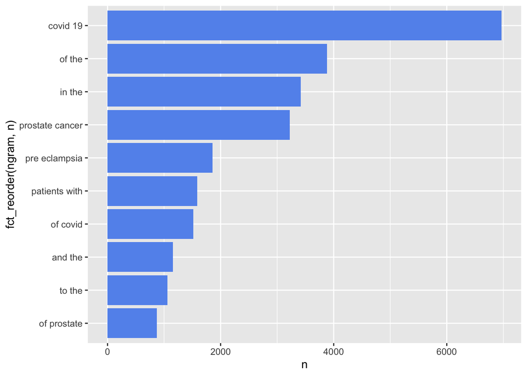

```r
pubmed |>
  unnest_ngrams(ngram,abstract, n =2) |> #Instead of creating words into tokens, making two word phrases = bigrams
  count(ngram, sort = TRUE) |>
  top_n(10,n)|>
  ggplot(aes(n, fct_reorder(ngram, n))) +
  geom_col(fill = "cornflowerblue")
```

### 3. Calculate the TF-IDF value for each word-search term combination. What are the 5 tokens from each search term with the highest TF-IDF value? How are the results different from the answers you got in question 1?

Below is the table that shows the top 5 tokens from each search term with the highest TF-IDF value.

These results are different from question 1 because rather than counting the number of times each words appears in the dataset `pubmed`, this counts each search term (i.e. covid, preeclampsia, cystic fibrosis (from the variable column `term`)’s most common tokens, and orders them based off their TF-IDF scores.

```r
pubmed_tf_idf <- pubmed |>
  unnest_tokens(word, abstract) |>
  count(term, word) |>
  bind_tf_idf(word, term, n)

top_5_tokens <- pubmed_tf_idf |>
  group_by(term)|>
  slice_max(tf_idf, n = 5) |>
  arrange(term, desc(tf_idf))

library(DT)
datatable(top_5_tokens,
          class = 'cell-border stripe',
          options = list(pageLength = 10,
                         lengthMenu = c(5, 10, 20, 50),
                         searching = TRUE,
                         ordering = TRUE))
```

|  | term | word | n | tf | idf | tf_idf |
| --- | --- | --- | --- | --- | --- | --- |
| 1 | covid | covid | 7275 | 0.03710504169535613 | 1.6094379124341 | 0.05971826084695422 |
| 2 | covid | pandemic | 800 | 0.004080279499145692 | 1.6094379124341 | 0.006566956519252699 |
| 3 | covid | coronavirus | 647 | 0.003299926044934078 | 1.6094379124341 | 0.00531102608494562 |
| 4 | covid | sars | 372 | 0.001897329967102747 | 1.6094379124341 | 0.003053634781452505 |
| 5 | covid | cov | 334 | 0.001703516690893326 | 1.6094379124341 | 0.002741704346788001 |
| 6 | cystic fibrosis | cf | 625 | 0.01271876271876272 | 0.9162907318741551 | 0.01165408440010881 |
| 7 | cystic fibrosis | fibrosis | 867 | 0.01764346764346764 | 0.5108256237659907 | 0.009012735364369433 |
| 8 | cystic fibrosis | cystic | 862 | 0.01754171754171754 | 0.5108256237659907 | 0.008960758805174685 |
| 9 | cystic fibrosis | cftr | 86 | 0.00175010175010175 | 1.6094379124341 | 0.002816680107231026 |
| 10 | cystic fibrosis | sweat | 83 | 0.001689051689051689 | 1.6094379124341 | 0.002718423824420641 |

[output cut: 15 more lines]

## Sentiment Analysis

### 1. Perform a sentiment analysis using the NRC lexicon. What is the most common sentiment for each search term?

Visualized in the table below are the top 3 sentiments for each search term. Some have a mixture of “positive” and “negative” sentiments, while others have “fear” or “anticipation.”

```r
nrc_lexicon <- get_sentiments("nrc")
pubmed_sentiments <- pubmed |>
  unnest_tokens(word, abstract) |>
  inner_join(nrc_lexicon, by = "word", relationship = "many-to-many")

top3_sentiments <- pubmed_sentiments |>
  count(term, sentiment, sort = TRUE) |>
  group_by(term)|>
  slice_max(n, n = 3) |>
  ungroup()

top3_sentiments
```

```
# A tibble: 15 × 3
   term            sentiment        n
   <chr>           <chr>        <int>
 1 covid           positive      9874
 2 covid           negative      9452
 3 covid           fear          7730
 4 cystic fibrosis positive      2747
 5 cystic fibrosis negative      2079
 6 cystic fibrosis disgust       1714
 7 meningitis      negative      2109
 8 meningitis      positive      1928
 9 meningitis      fear          1510
10 preeclampsia    positive      8014
11 preeclampsia    negative      7032
12 preeclampsia    anticipation  4780
13 prostate cancer negative      8918
14 prostate cancer fear          8118
15 prostate cancer positive      7121
```

#### What if you remove “positive” and “negative” from the list?

```r
common_sentiment_exclusive <- pubmed_sentiments|>
  filter(!sentiment %in% c("positive", "negative")) |>
  count(term, sentiment, sort = TRUE) |>
  group_by(term) |>
  slice_max(n, n = 3) |>
  ungroup()

common_sentiment_exclusive #Removal of the "positive" and "negative" sentiments
```

```
# A tibble: 15 × 3
   term            sentiment        n
   <chr>           <chr>        <int>
 1 covid           fear          7730
 2 covid           trust         5897
 3 covid           sadness       5587
 4 cystic fibrosis disgust       1714
 5 cystic fibrosis trust         1642
 6 cystic fibrosis fear          1517
 7 meningitis      fear          1510
 8 meningitis      trust         1090
 9 meningitis      sadness       1032
10 preeclampsia    anticipation  4780
11 preeclampsia    trust         3941
12 preeclampsia    fear          3558
13 prostate cancer fear          8118
14 prostate cancer sadness       6345
15 prostate cancer anger         5794
```

### 2. Now perform a sentiment analysis using the AFINN lexicon to get an average positivity score for each abstract (hint: you may want to create a variable that indexes, or counts, the abstracts).

```r
afinn_lexicon <- get_sentiments("afinn")
pubmed_sentiments_afinn <- pubmed |>
  mutate(abstract_id = row_number()) |>  # Create an abstract index
  unnest_tokens(word, abstract) |>
  inner_join(afinn_lexicon, by = "word")

average_positivity <- pubmed_sentiments_afinn |> #Calculating the average positivity
  group_by(abstract_id) |>
  summarize(avg_score = mean(value, na.rm = TRUE)) |>
  ungroup()

average_positivity
```

```
# A tibble: 3,163 × 2
   abstract_id avg_score
         <int>     <dbl>
 1           1    -1.13
 2           2    -2
 3           3     0.214
 4           4    -0.8
 5           5    -1.67
 6           6    -0.143
 7           7     0.167
 8           8     0.909
 9           9    -0.222
10          10    -1.62
# ℹ 3,153 more rows
```

#### Create a visualization that shows these scores grouped by search term. Are any search terms noticeably different from the others?

The search term “prostate cancer” is noticeably different the other search terms as well as “cystic fibrosis” for opposite reasons. The search term “prostate cancer” has the smallest IQR (reflected in the size the box plot). The search term “cystic fibrosis” has a noticeably larger IQR, but this search term stands out the most among the other search terms because its difference in median value (reflected in the placement of the horizontal line in the middle of the box plot).

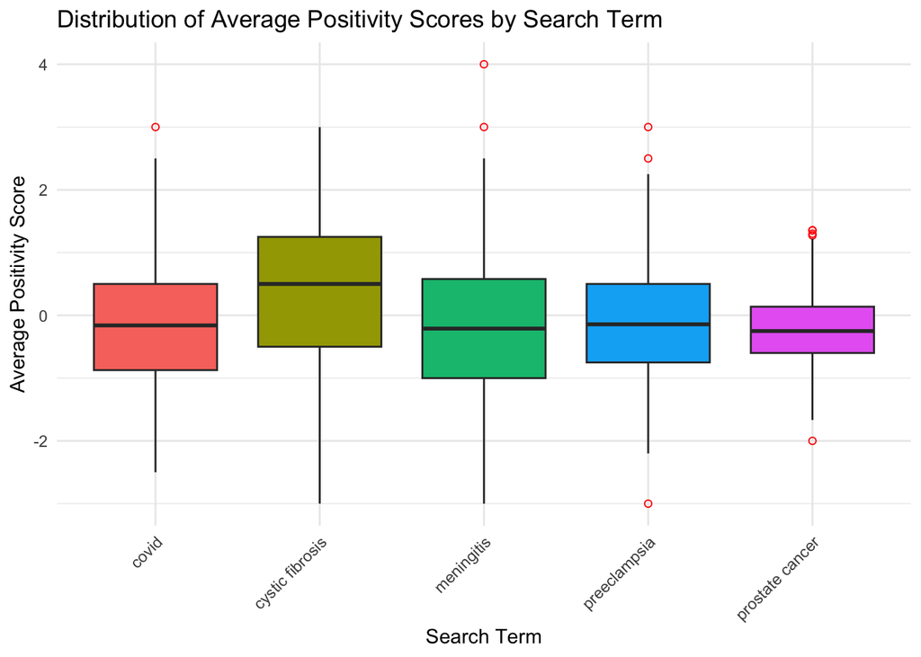

```r
pubmed_with_scores <- pubmed %>%
  mutate(abstract_id = row_number()) %>%
  left_join(average_positivity, by = "abstract_id")
#Plotting visualization
ggplot(pubmed_with_scores, aes(x = term, y = avg_score, fill = term)) +
  geom_boxplot(outlier.color = "red", outlier.shape = 1) +
  labs(title = "Distribution of Average Positivity Scores by Search Term",
       x = "Search Term",
       y = "Average Positivity Score") +
  theme_minimal() +
  theme(axis.text.x = element_text(angle = 45, hjust = 1)) +
  guides(fill = FALSE)
```